Jacob F. Brumley and Rebecca E. Blanton Johansen Lab of Ichthyology at Austin Peay State University, Department of Biology and Center of Excellence for Field Biology

This `RMarkdown` was created by the Johansen Lab for use in population genetics studies. Compiled as a functional list of code for various packages used for genetic analyses.

Each chunk of code is specific for a certain R package.

Within each code: “datagenind” will be the genind object the data file is saved.

In this Markdown document, I will be demonstrating an example of loading the genotype data into R in the *genepop* format. Note that both “DaTa.txt” and “DaTa.gen” are the same files in different formats. I would create the “DaTa.txt” file from the genotype data, copy and paste in another folder, change the file type to “.gen”, and move both it into the project folder.

I have added example data documents (“.txt” and “.gen” files) into the ‘Inputs’ folder of the R-Project. The “DaTa.txt”/“DaTa.gen” and “NB.txt” files are accompanied with explanation “.txt” files that explain the format for each document.

For help with *genepop* format reference:

http://www.med.kagawa-u.ac.jp/~genomelb/takezaki/poptree2/test_genepop.html

**Instruction:**

**First**, create an R-Project with a set directory.

**Second**, within the project folder, create an ‘inputs’ folder where you store your genotype data (in *genepop* format in two identical documents - one a “.txt” file and the other in a “.gen” file).

**Third**, create an RMarkdown document (.Rmd) and code away!

# Setup

```r
#Clear R's Brain
rm(list = ls())

#Install Packages Needed
packages_needed <- c("dplyr", "knitr", "tidyverse", "genetics",
                     "adegenet", "ade4", "ape", "pegas",
                     "hierfstat", "PopGenReport", "genepop",
                     "diveRsity", "nnet", "mmod", "poppr", "NB")
pk_to_install <- packages_needed [!( packages_needed %in% rownames(installed.packages())  )]
if(length(pk_to_install)>0 ){
  install.packages(pk_to_install,repos="http://cran.r-project.org")}

#Loading Packages Needed
library(dplyr)
library(knitr)
library(tidyverse)
library(genetics)
library(adegenet)
library(ade4)
library(pegas)
library(ape)
library(hierfstat)
library(PopGenReport)
library(genepop)
library(diveRsity)
library(nnet)
library(mmod)
library(poppr)
library(NB)

#Data Input from Input folder
datagenepop <- "Inputs/DaTa.gen" #Creates an object for genepop file
datagenind <- read.genepop("Inputs/DaTa.gen") #Converts genepop to genind
datahierfstat <-genind2hierfstat(datagenind) #Converts genind to hierfstat
NB <- "Inputs/NB.txt" #Creates an object for NB file
```

# genepop

```r
#Genepop will read your input file as a .txt document
#Testing for Linkage Disequilibrium between loci
test_LD("Inputs/DaTa.txt",
        outputFile = "Results/LD.txt",
        dememorization = 10000, batches = 1000, iterations = 10000,
        verbose = interactive())
#Testing for deviation from HWE usign exact tests (loci, population, and species as a whole)
test_HW("Inputs/DaTa.txt", which = "Proba",
        outputFile = "Results/HWE.txt",
        enumeration = FALSE, dememorization = 10000, batches = 1000,
        iterations = 10000, verbose = interactive())
#Both functions will produce a .txt file of the results in the "Results" folder.
```

# PopGenReport

```r
popgenreport(datagenind, foldername = "Results/PopGenReport",
             mk.complete = TRUE, mk.Rcode = TRUE, mk.pdf = TRUE,
             path.pgr = getwd())
#The popgenreport() function will provide you with graphics and results of basic genetic diversity functions.
#The graphics and results will be placed in a folder called "PopGenReport" in your Results folder (if you do not have a "PopGenReport" folder, the package will create one for you using this code).
```

# diveRsity

```r
divBasic(datagenepop,
         outfile = "Results/DivBasicResults.txt",
         gp = 2, bootstraps = 10000, HWEexact = TRUE, mcRep = 10000)
```

```
$locus_pop_size
        Ind01, Ind10, Ind19, Ind27,
Locus01      9      9      8      6
Locus02      9      9      8      6
Locus03      9      9      8      6
Locus04      9      9      8      6
Locus05      9      9      8      6
overall      9      9      8      6

$Allele_number
        Ind01, Ind10, Ind19, Ind27,
Locus01      4      5      4      4
Locus02      5      5      5      5
Locus03      3      3      3      4
Locus04      6      4      4      5
Locus05      3      4      4      3
overall     21     21     20     21

$proportion_Alleles
        Ind01, Ind10, Ind19, Ind27,
Locus01  66.67  83.33  66.67  66.67
Locus02  62.50  62.50  62.50  62.50
Locus03  75.00  75.00  75.00 100.00
Locus04  85.71  57.14  57.14  71.43
Locus05  60.00  80.00  80.00  60.00
overall  69.98  71.59  68.26  72.12

$Allelic_richness
        Ind01, Ind10, Ind19, Ind27,
Locus01   3.45   3.92   3.62   3.63
Locus02   3.76   3.74   3.85   3.91
Locus03   2.75   2.77   2.75   3.30
Locus04   4.69   3.57   3.30   4.37
Locus05   2.90   3.00   3.08   2.66
overall   3.51   3.40   3.32   3.57

$Ho
        Ind01, Ind10, Ind19, Ind27,
Locus01   0.78   0.56   0.75   0.83
Locus02   0.56   0.56   0.50   0.83
```

[output cut: 10 more lines]

```
Locus04   0.77   0.67   0.55   0.74
Locus05   0.59   0.54   0.63   0.61
overall   0.65   0.62   0.62   0.65

$HWE
        [,1]  [,2]  [,3]  [,4]
       0.776 0.234 0.555 1.000
       0.201 1.000 0.424 1.000
       0.224 0.224 1.000 0.251
       0.190 1.000 0.158 1.000
       0.108 0.000 0.162 0.067
HWEall 0.152 0.007 0.422 0.613

$fis
$fis[[1]]
```

|  | fis | lower_CI | upper_CI | BC_lower_CI | BC_upper_CI |
| --- | --- | --- | --- | --- | --- |
| Locus01 | -0.1560 | -0.5577 | 0.1910 | -0.4970 | 0.2517 |
| Locus02 | 0.1509 | -0.2743 | 0.5663 | -0.2286 | 0.6120 |
| Locus03 | 0.1910 | -0.4257 | 0.6250 | -0.3611 | 0.6897 |
| Locus04 | -0.1613 | -0.4595 | 0.0426 | -0.4026 | 0.0994 |
| Locus05 | -0.5158 | -0.8202 | -0.3500 | -0.7810 | -0.3108 |
| overall | -0.1013 | -0.3433 | -0.0020 | -0.2850 | 0.0563 |

```
$fis[[2]]
```

|  | fis | lower_CI | upper_CI | BC_lower_CI | BC_upper_CI |
| --- | --- | --- | --- | --- | --- |
| Locus01 | 0.2241 | -0.2727 | 0.6471 | -0.2177 | 0.7021 |
| Locus02 | 0.1089 | -0.3404 | 0.5325 | -0.2833 | 0.5896 |
| Locus03 | -0.0345 | -0.5000 | 0.2394 | -0.4476 | 0.2918 |
| Locus04 | 0.0000 | -0.4257 | 0.3899 | -0.3709 | 0.4448 |
| Locus05 | 0.1818 | -0.3846 | 0.7049 | -0.3259 | 0.7636 |
| overall | 0.1000 | -0.1297 | 0.1656 | -0.0715 | 0.2238 |

```
$fis[[3]]
```

|  | fis | lower_CI | upper_CI | BC_lower_CI | BC_upper_CI |
| --- | --- | --- | --- | --- | --- |
| Locus01 | -0.0787 | -0.6410 | 0.2727 | -0.5655 | 0.3483 |
| Locus02 | 0.2471 | -0.2308 | 0.6098 | -0.1784 | 0.6622 |
| Locus03 | 0.0588 | -0.4933 | 0.5897 | -0.4188 | 0.6643 |
| Locus04 | -0.1268 | -0.6000 | 0.1795 | -0.5376 | 0.2419 |
| Locus05 | 0.2099 | -0.5342 | 0.7681 | -0.4511 | 0.8513 |
| overall | 0.0660 | -0.2643 | 0.2099 | -0.1964 | 0.2778 |

```
$fis[[4]]
```

|  | fis | lower_CI | upper_CI | BC_lower_CI | BC_upper_CI |
| --- | --- | --- | --- | --- | --- |
| Locus01 | -0.1765 | -0.6364 | 0.1429 | -0.5488 | 0.2304 |
| Locus02 | -0.3636 | -0.6364 | -0.2000 | -0.5676 | -0.1313 |
| Locus03 | -0.4286 | -0.7561 | -0.2414 | -0.6934 | -0.1787 |
| Locus04 | -0.3585 | -0.7561 | -0.2857 | -0.6713 | -0.2009 |
| Locus05 | -0.0909 | -1.0000 | 0.4545 | -0.8814 | 0.5731 |
| overall | -0.2821 | -0.6552 | -0.1745 | -0.5689 | -0.0882 |

```
$arCIs
         Ind01, Ind10, Ind19, Ind27,
Lower_CI    2.8    2.6  2.595    2.8
Upper_CI    4.0    4.0  4.000    4.2

$mainTab
$mainTab$`Ind01,`
```

| stats | Locus01 | Locus02 | Locus03 | Locus04 | Locus05 | overall |
| --- | --- | --- | --- | --- | --- | --- |
| N | 9 | 9 | 9 | 9 | 9 | 9 |
| A | 4 | 5 | 3 | 6 | 3 | 21 |
| % | 66.67 | 62.5 | 75 | 85.71 | 60 | 69.98 |
| Ar | 3.45 | 3.76 | 2.75 | 4.69 | 2.9 | 3.51 |
| Ho | 0.78 | 0.56 | 0.44 | 0.89 | 0.89 | 0.71 |
| He | 0.67 | 0.65 | 0.55 | 0.77 | 0.59 | 0.65 |
| HWE | 0.776 | 0.201 | 0.224 | 0.19 | 0.108 | 0.152 |
| Fis | -0.156 | 0.151 | 0.191 | -0.161 | -0.516 | -0.101 |
| Fis_Low | -0.497 | -0.229 | -0.361 | -0.403 | -0.781 | -0.285 |
| Fis_High | 0.252 | 0.612 | 0.69 | 0.099 | -0.311 | 0.056 |

```
$mainTab$`Ind10,`
```

| stats | Locus01 | Locus02 | Locus03 | Locus04 | Locus05 | overall |
| --- | --- | --- | --- | --- | --- | --- |
| N | 9 | 9 | 9 | 9 | 9 | 9 |
| A | 5 | 5 | 3 | 4 | 4 | 21 |
| % | 83.33 | 62.5 | 75 | 57.14 | 80 | 71.59 |
| Ar | 3.92 | 3.74 | 2.77 | 3.57 | 3 | 3.4 |
| Ho | 0.56 | 0.56 | 0.56 | 0.67 | 0.44 | 0.56 |
| He | 0.72 | 0.62 | 0.54 | 0.67 | 0.54 | 0.62 |
| HWE | 0.234 | 1 | 0.224 | 1 | 0 | 0.007 |
| Fis | 0.224 | 0.109 | -0.034 | 0 | 0.182 | 0.1 |
| Fis_Low | -0.218 | -0.283 | -0.448 | -0.371 | -0.326 | -0.072 |
| Fis_High | 0.702 | 0.59 | 0.292 | 0.445 | 0.764 | 0.224 |

```
$mainTab$`Ind19,`
```

| stats | Locus01 | Locus02 | Locus03 | Locus04 | Locus05 | overall |
| --- | --- | --- | --- | --- | --- | --- |
| N | 8 | 8 | 8 | 8 | 8 | 8 |
| A | 4 | 5 | 3 | 4 | 4 | 20 |
| % | 66.67 | 62.5 | 75 | 57.14 | 80 | 68.26 |
| Ar | 3.62 | 3.85 | 2.75 | 3.3 | 3.08 | 3.32 |
| Ho | 0.75 | 0.5 | 0.5 | 0.62 | 0.5 | 0.58 |
| He | 0.7 | 0.66 | 0.53 | 0.55 | 0.63 | 0.62 |
| HWE | 0.555 | 0.424 | 1 | 0.158 | 0.162 | 0.422 |
| Fis | -0.079 | 0.247 | 0.059 | -0.127 | 0.21 | 0.066 |
| Fis_Low | -0.566 | -0.178 | -0.419 | -0.538 | -0.451 | -0.196 |
| Fis_High | 0.348 | 0.662 | 0.664 | 0.242 | 0.851 | 0.278 |

```
$mainTab$`Ind27,`
```

| stats | Locus01 | Locus02 | Locus03 | Locus04 | Locus05 | overall |
| --- | --- | --- | --- | --- | --- | --- |
| N | 6 | 6 | 6 | 6 | 6 | 6 |
| A | 4 | 5 | 4 | 5 | 3 | 21 |
| % | 66.67 | 62.5 | 100 | 71.43 | 60 | 72.12 |
| Ar | 3.63 | 3.91 | 3.3 | 4.37 | 2.66 | 3.57 |
| Ho | 0.83 | 0.83 | 0.83 | 1 | 0.67 | 0.83 |
| He | 0.71 | 0.61 | 0.58 | 0.74 | 0.61 | 0.65 |
| HWE | 1 | 1 | 0.251 | 1 | 0.067 | 0.613 |
| Fis | -0.176 | -0.364 | -0.429 | -0.358 | -0.091 | -0.282 |
| Fis_Low | -0.549 | -0.568 | -0.693 | -0.671 | -0.881 | -0.569 |
| Fis_High | 0.23 | -0.131 | -0.179 | -0.201 | 0.573 | -0.088 |

```r
#The divBasic() function will produce measures of allelic richness (with CI; by rarefaction), allele numbers for populations, observed and expected heterozygosity, and inbreeding coefficients (Fis with CI).
```

# NB

```r
#Effective Population Size
NB.estimator(NB, alleles = rep(4,5), sample.interval = c(0, 2),
             bound = c(10, 1e7), profile.likelihood = TRUE)
```

```
$N
[1] 9999999

$CI
[1] 1.09264e+02 1.00000e+07

$log.like
[1] -42.44133

$profile.CI
           log.like         N
  [1,]      109.264 -44.44132
  [2,]   101118.261 -42.44363
  [3,]   202127.259 -42.44247
  [4,]   303136.256 -42.44208
```

[output cut: 96 more lines]

```
         log.like         N
   [1,]  10.00000 -54.77220
   [2,]  10.09009 -54.70712
   [3,]  10.18018 -54.64284
   [4,]  10.27027 -54.57934
   [5,]  10.36036 -54.51662
   [6,]  10.45045 -54.45465
   [7,]  10.54054 -54.39342
   [8,]  10.63063 -54.33291
   [9,]  10.72072 -54.27312
  [10,]  10.81081 -54.21402
  [11,]  10.90090 -54.15560
  [12,]  10.99099 -54.09785
  [13,]  11.08108 -54.04076
  [14,]  11.17117 -53.98431
```

[output cut: 487 more lines]

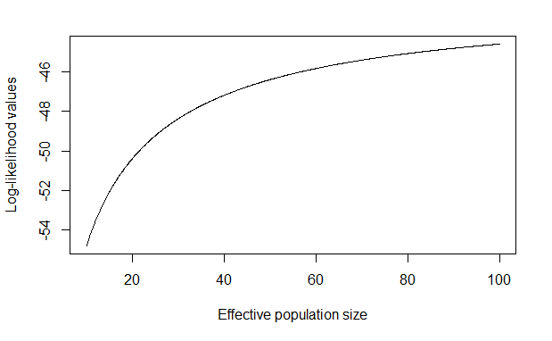

```r
NB.plot.likelihood(NB, alleles = rep(4,5), sample.interval = c(0, 2),
                   lb = 10, ub = 100, step = 1000)
```

```r
#alleles = rep(4,5) is saying that there are 5 loci with 4 alleles each
#sample.interval = c(0, 2) is saying that temporal unit 1 is generation 0 and temporal unit 2 is generation 2
```

# hierfstat

```r
#Weir-Cockerham Pairwise Fst (Fixation between poplations)
pairwise.WCfst(datahierfstat, diploid = TRUE)
```

```
            Ind09        Ind18        Ind26       Ind32
Ind09          NA -0.022342427 -0.017311252 -0.01772141
Ind18 -0.02234243           NA -0.008554427 -0.02924061
Ind26 -0.01731125 -0.008554427           NA  0.01593156
Ind32 -0.01772141 -0.029240612  0.015931560          NA
```

```r
#CI for pairwise Fst
boot.ppfst(datahierfstat, nboot = 10000,
           quant = c(0.025, 0.975), diploid = TRUE)
```

```
       Upper limit above diagonal
       Lower limit below diagonal

            Ind09        Ind18       Ind26       Ind32
Ind09          NA  0.006036932  0.02048907 0.001979428
Ind18 -0.05158133           NA  0.02092630 0.003326026
Ind26 -0.05824115 -0.035258359          NA 0.085540797
Ind32 -0.04059250 -0.060699694 -0.03232537          NA
```

```r
#Weir-Cockerham Fst and Fis for species as a whole
wc(datahierfstat, diploid = TRUE)
```

```
$FST
[1] -0.01413661

$FIS
[1] 0.02670492
```

# adegenet

```r
Fst <- matrix(c(-0.02234243, -0.01731125, -0.01772141,
                 NA, -0.008554427, -0.029240612,
                 NA, NA, 0.015931560),
               nrow = 3, ncol = 3)
Fst
```

```
            [,1]         [,2]       [,3]
[1,] -0.02234243           NA         NA
[2,] -0.01731125 -0.008554427         NA
[3,] -0.01772141 -0.029240612 0.01593156
```

```r
Fst.matrix <- as.matrix(Fst)
Fst.dis <- as.dist(Fst.matrix) #Converts matrix to distance object
#Form matrix with the log transformed geographic distances (Km) between populations
river <- matrix(c(0.728353782, 1.198106999, 1.43964843,
                   NA, 0.773786445, 1.247482261,
                   NA, NA, 1.069668097),
                nrow = 3, ncol = 3)
river
```

```
          [,1]      [,2]     [,3]
[1,] 0.7283538        NA       NA
[2,] 1.1981070 0.7737864       NA
[3,] 1.4396484 1.2474823 1.069668
```

```r
river.matrix <- as.matrix(river)
river.dis <- as.dist(river.matrix) #Converts matrix to distance object
#Mantel random permutation test to determine IBD
mantel.randtest(river.dis, Fst.dis, nrepet=10000)
```

```
Monte-Carlo test
Call: mantel.randtest(m1 = river.dis, m2 = Fst.dis, nrepet = 10000)

Observation: 0.2942056

Based on 10000 replicates
Simulated p-value: 0.6613339
Alternative hypothesis: greater

    Std.Obs Expectation    Variance
 0.43047101 -0.01047764  0.50096708
```